### thematic maps of Kaohsiung city public bike

```
library(sp)
library(tmap)
library(tmaptools)
library(plyr)
library(dplyr)
library(ggplot2)
library(lubridate)

sp：空間數據處理套件
tmap & tmaptools：地圖套件及相關工具
plyr & dplyr：數據操作(Data Manipulation)工具
ggplot2：繪圖及空間可視化
lubridate：日期時間處理套件
```

主題地圖( thematic map )是呈現空間數據的一種方法，這次練習的資料來源為[高雄市公共腳踏車資訊網](http://www.c-bike.com.tw/)，網站中有提供[即時更新的XML](http://www.c-bike.com.tw/xml/stationlistopendata.aspx)，以下做法是利用排程套件 taskscheduleR 從 8:30 至 18:00 ，每10分鐘擷取、解析，得到資料共 10846 筆，資料結構如下：sID 是原 XML 的 StationID，sNO 是 StationNO，sName 是 StationName，Lat 是 StationLat，Lon 是 StationLon，stock 是 StationNums1(目前數量)，space 是 StationNums2(尚餘空位)，avRate 是自訂的可租率，公式:stock / (stock + space)，Alert 是可租率低於1成時的 Station 名稱，relativeIndex 是自訂的相對比率，加強目前數量和尚餘空位的對比，公式:1 / ((stock + 1) / (space + 1))，Dtime 是資料擷取時的日期時間

```r
str(kaoBike)
```

```
## 'data.frame':    10846 obs. of  11 variables:
##  $ sID          : int  1 2 3 4 5 6 7 8 9 10 ...
##  $ sNO          : int  19 22 18 17 16 3 9 21 28 10 ...
##  $ sName        : chr  "生態園區站" "巨蛋站" "凹仔底站" "後驛站" ...
##  $ Lat          : num  22.7 22.7 22.7 22.6 22.6 ...
##  $ Lon          : num  120 120 120 120 120 ...
##  $ stock        : int  16 10 11 14 4 7 1 1 9 0 ...
##  $ space        : int  12 22 21 18 28 25 31 31 23 32 ...
##  $ avRate       : num  57.1 31.2 34.4 43.8 12.5 ...
##  $ Alert        : chr  NA NA NA NA ...
##  $ relativeIndex: num  0.765 2.091 1.833 1.267 5.8 ...
##  $ Dtime        : POSIXct, format: "2017-01-19 08:30:05" "2017-01-19 08:30:05" ...
```

首先，利用 sp 套件以經緯度建立公共腳踏車數據的空間物件(SpatialPointsDataFrame)，接著利用 tmaptools 套件設定其 projection

```r
# 建立 bike SpatialPointsDataFrame of known locations
SPT <- kaoBike
coordinates(SPT) <- ~ Lon + Lat
SPT <- set_projection(SPT, current.projection = 'longlat', projection = 'hd')
get_projection(SPT)
```

```
## [1] "+proj=cea +lat_ts=37.5 +ellps=WGS84 +datum=WGS84 +units=m +no_defs +towgs84=0,0,0"
```

地圖的部份，使用各鄉(鎮、市、區)行政區域界線圖資，從[政府資料開放平台](http://data.gov.tw/node/7441)下載，讀入 shapefile 之後留下高雄市的部份並重設 projection ，然後繪出高雄市地圖確認

```r
# 建立高雄行政區地圖
# download districts borders of KaoHsiung from http://data.gov.tw/node/7441
TW <- read_shape(file = file.path("data", "tw_county3", "TOWN_MOI_1051214.shp"),
                    encoding = 'UTF-8', use_iconv=T)
kaoMAP <- TW[which(TW$COUNTYNAME == "高雄市"),]
kaoMAP <- set_projection(kaoMAP, projection = 'hd')
get_projection(kaoMAP)
qtm(kaoMAP)
```

```
## [1] "+proj=cea +lat_ts=37.5 +ellps=WGS84 +datum=WGS84 +units=m +no_defs +towgs84=0,0,0"
```

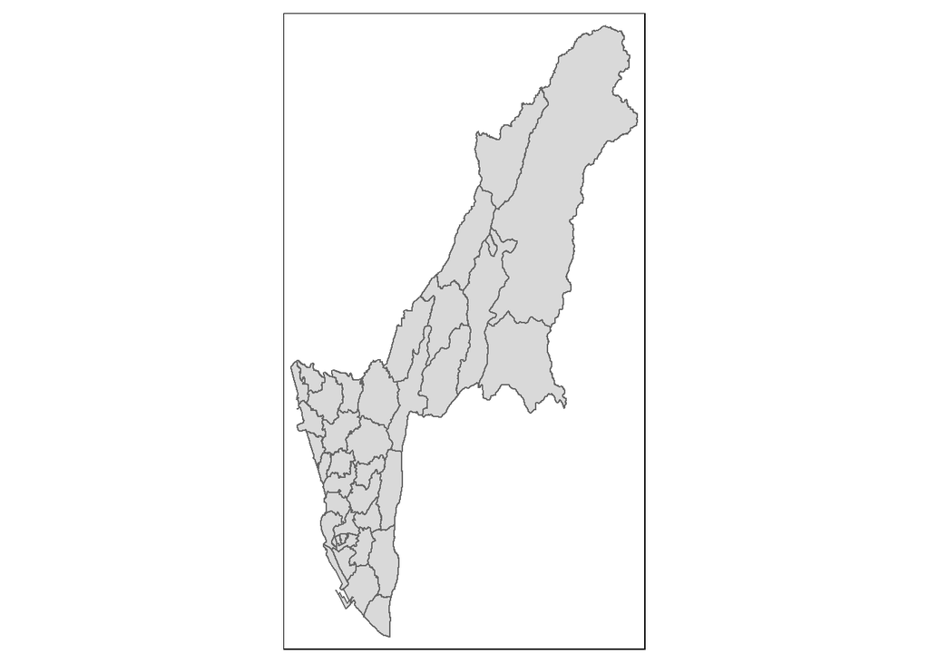

接著，整合公共腳踏車空間物件與高雄地圖的資訊，利用 sp 套件 over 方法，將高雄地圖中有的資訊(ex:行政區)擷取整合(類似 join 的概念)。由於並非所有行政區都有公共腳踏車的 Station，利用整合後的資訊進行過濾，重設 projection 後繪出有公共腳踏車的行政區地圖來查看

```r
# retrieves KaoHsiung attributes into SPT
spatial.kao <- over(SPT, kaoMAP)
# remove bike 沒用到的行政區
bikeMAP <- kaoMAP[which(kaoMAP$TOWNNAME %in% unique(as.character(spatial.kao$TOWNNAME))),]
bikeMAP <- set_projection(bikeMAP, projection = 'hd')
get_projection(bikeMAP)
tm_shape(bikeMAP) + tm_fill("grey70") + tm_borders(col = 'white') +
  tm_text("TOWNNAME", size = 0.7)
```

```
## [1] "+proj=cea +lat_ts=37.5 +ellps=WGS84 +datum=WGS84 +units=m +no_defs +towgs84=0,0,0"
```

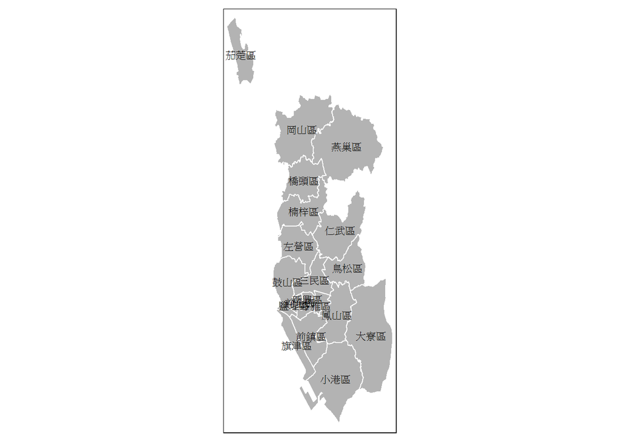

有了整合後的 spatial.kao 資訊，在與公共腳踏車數據 kaoBike 確認筆數無誤後合併，成為最後要使用的資料來源。首先，利用它來了解一下高雄各行政區的平均可租率，紅色虛線是自訂的警示線，低於此線可能面臨缺車，不過由於各區 Station 數量及公共腳踏車租借情形不一，從各區平均可租率看來似乎還好

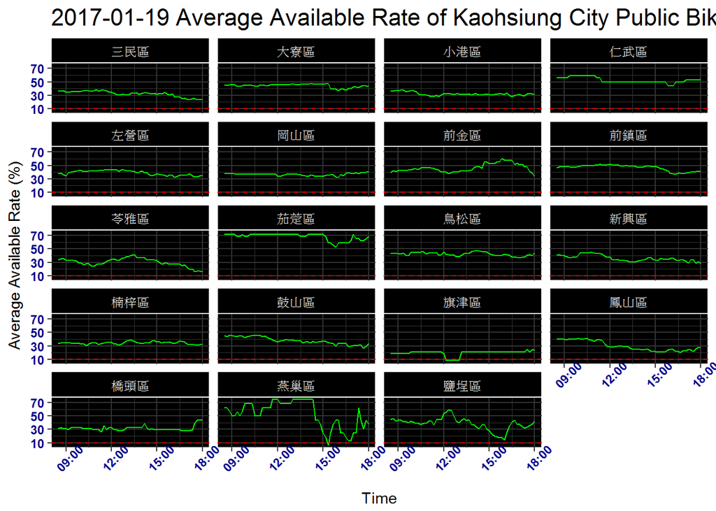

19 個行政區公共腳踏車 Station 數量如下，最多的是左營區有 25 個、最少的是燕巢區 1 個

| 三民區 | 大寮區 | 小港區 | 仁武區 | 左營區 | 岡山區 | 前金區 | 前鎮區 | 苓雅區 | 茄萣區 | 鳥松區 | 新興區 | 楠梓區 | 鼓山區 | 旗津區 | 鳳山區 | 橋頭區 | 燕巢區 | 鹽埕區 |
| --- | --- | --- | --- | --- | --- | --- | --- | --- | --- | --- | --- | --- | --- | --- | --- | --- | --- | --- |
| 24 | 5 | 9 | 2 | 25 | 6 | 8 | 24 | 20 | 2 | 7 | 9 | 10 | 12 | 3 | 15 | 2 | 1 | 3 |

以苓雅區為例，有 20 個 Station ，個別的可租率分佈如下圖，可以用來了解每個 Station 在不同時段公共腳踏車使用情形，做為車輛調度改善的參考

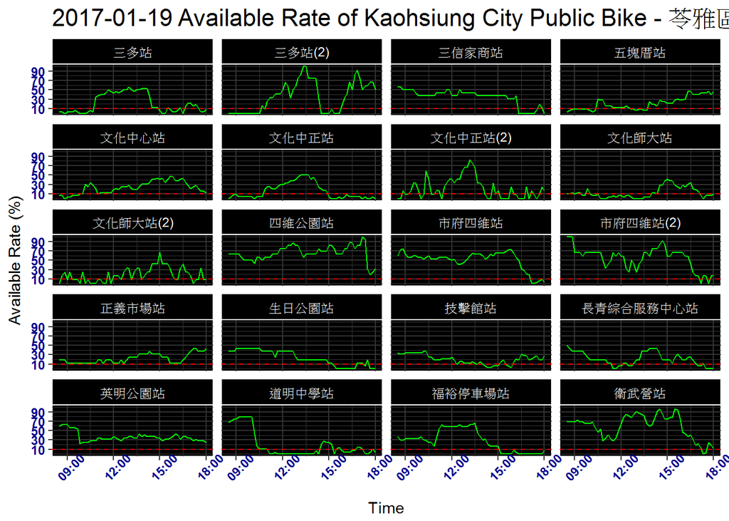

下圖是各行政區公共腳踏車出現 Alert 次數情形(以每 10 分鐘為計算周期)，有 16 區出現 Alert 情形，其中以旗津區的次數為最高，表示該區某 Station 可能在某時段長時間缺車

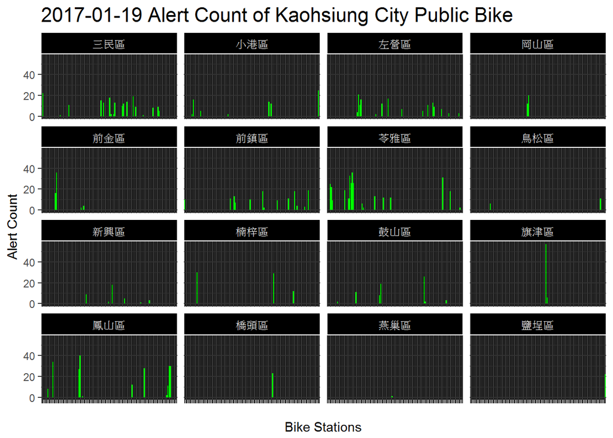

進一步確認旗津區各 Station 租借情形，海科大旗津站(1)在當日的確缺車嚴重

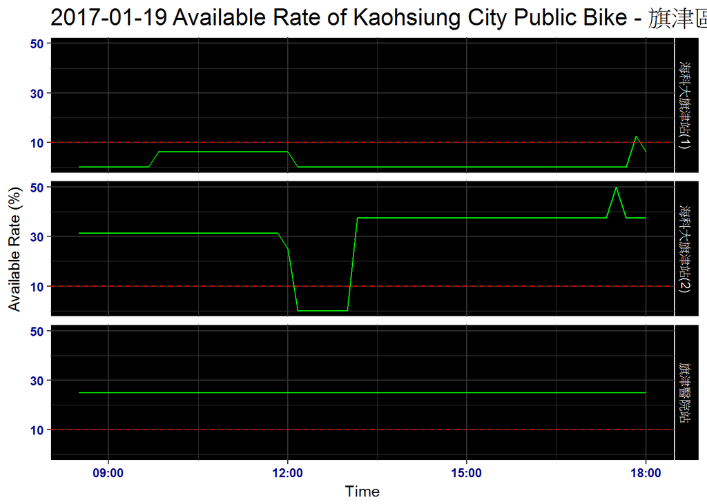

最後，利用 tmap 套件將數據及 shapefile 製成主題地圖，結合免費軟體 ImageMagick 的安裝，產出 gif 動畫圖，運用地理空間的呈現幫助了解各區 Station 在每個時間點腳踏車的租借情形

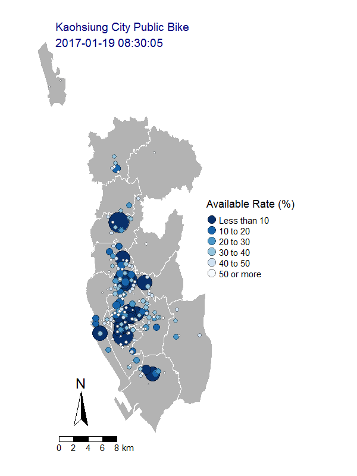

也可以 focus 在個別行政區，以使用頻繁的三民、新興、苓雅及前鎮區為例

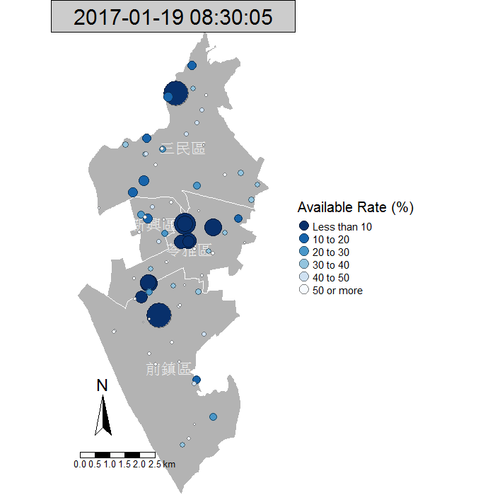

### Lessons Learned:

#### Spatial Data & Thematic Maps